# AppliedAlpha(2)

```python
import numpy as np
import pandas as pd
from matplotlib import pyplot as plt
import scipy.stats as st
from scipy import mean
import datetime
import warnings

warnings.simplefilter("ignore")
```

```python
df = pd.read_csv("SPY - SPY.csv")
df.head()
```

|  | date | open | high | low | close | volume |
| --- | --- | --- | --- | --- | --- | --- |
| 0 | 2000-01-03 | 107.404545 | 107.404545 | 104.234934 | 105.366938 | 8164300.0 |
| 1 | 2000-01-04 | 103.985859 | 104.370774 | 101.167180 | 101.246443 | 8089800.0 |
| 2 | 2000-01-05 | 101.382283 | 102.536894 | 99.435236 | 101.427563 | 12177900.0 |
| 3 | 2000-01-06 | 101.155883 | 102.514288 | 99.797478 | 99.797478 | 6227200.0 |
| 4 | 2000-01-07 | 101.653964 | 105.593338 | 101.472843 | 105.593338 | 8066500.0 |

1. Постройте график кривой доходности такой торговой модели (equity curve) для имеющихся исторических даних. Какую конечную прибыль получил бы инвестор?

```python
purchase = 0
selling = 0
portfolio = 0
value = 0
df["equity"] = 0
for i in range(13, len(df)):
    if portfolio == 0 and df["close"].loc[i] > df["close"].loc[i-13]:
        portfolio = 1
        purchase = df["close"].loc[i]
    elif portfolio == 1 and df["close"].loc[i] < df["close"].loc[i-13]:
        portfolio == 0
        selling = df["close"].loc[i]
        value = purchase - selling
        df["equity"].loc[i] = value
    else:
        df["equity"].loc[i] = value
```

```python
equity = pd.DataFrame({"equity": df["equity"].values}, index=df["date"])
```

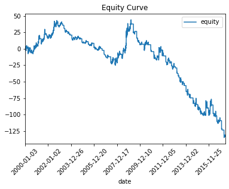

```python
equity.plot()
plt.xticks(rotation=45)
plt.title("Equity Curve")
plt.show()
```

```python
print("Конечная прибыль:", round(equity["equity"].to_list()[-1], 6))
```

```
Конечная прибыль: -132.913425
```

1. Оцените среднюю дневную доходность и дисперсию дневной доходности для такой модели.

```python
print("Средняя дневная доходность:", equity["equity"].mean())
print("Дисперсия дневной доходноти:", equity["equity"].var())
```

```
Средняя дневная доходность: -15.919012454399283
Дисперсия дневной доходноти: 1869.6228516444758
```

1. Попытайтесь проверить следующую гипотезу: некоторые дни недели наиболее предпочтительны для входа в позицию (приносит больше прибыли)

```python
df["day"] = df["date"].apply(lambda x: datetime.datetime.strptime(x, "%Y-%m-%d").strftime("%A"))
week = {}
for key in set(df["day"].values):
    week[key] = df[df["day"] == key]["close"].values
```

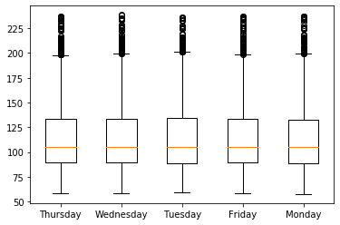

```python
fig, ax = plt.subplots()
ax.boxplot(week.values())
ax.set_xticklabels(week.keys())
plt.show()
```

Судя по сюжету выше, то гипотеза не подтверждаеться. Но мы проведем еще одну проверку.

Чтобы проверить эту гипотезу, мы посчитаем среднее значение цены акции на момент закрытия для каждого дня недели.

```python
week_mean_exp = [df["close"].sum()/len(df)] * 5
week_mean_obs = [mean(week[key]) for key in week]
```

```python
print("Ожидаемые значения:", week_mean_exp)
print("Наблюдаемые значения:", week_mean_obs)
```

```
Ожидаемые значения: [120.00965932621182, 120.00965932621182, 120.00965932621182, 120.00965932621182, 120.00965932621182]
Наблюдаемые значения: [120.12963667274802, 120.0846582312849, 120.10000585313901, 119.91914024655964, 119.7966842741738]
```

H0: (нулевая гипотеза) Переменная следует гипотетическому распределению.

H1: (альтернативная гипотеза) Переменная не следует гипотетическому распределению.

```python
st.chisquare(week_mean_obs, week_mean_exp)
```

```
Power_divergenceResult(statistic=0.0006810616028943167, pvalue=0.9999999420325477)
```

Поскольку значение p (0.999) не менее 0.05, мы не можем отвергнуть нулевую гипотезу. Это означает, что у нас нет достаточных доказательств, чтобы утверждать, что некоторые дни недели наиболее предпочтительны для входа в позицию.

1. Оцените продолжительность периода максимального убытка для даной торговой модели в днях

```python
lesion = []
flag = False
temp = []
for i in range(len(equity)):
    if not flag and equity["equity"].values[i] < 0:
        flag = True
    if flag and equity["equity"].values[i] >= 0:
        flag = False
        lesion.append(temp)
        temp = []
    if flag:
        temp.append(equity["equity"].values[i])

print("Продолжительность периода максимального убытка составляет", max([len(item) for item in lesion]))
```

```
Продолжительность периода максимального убытка составляет 465
```

1. Оцените максимальный убыток в USD, который принесла бы такая торговая модель.

```python
print("Максимальный убыток в USD", min([sum(item) for item in lesion]))
```

```
Максимальный убыток в USD -5627.928660999997
```

1. Как бы вы оценили минимальную сумму в USD, которую мог бы потерять инвестор с вероятностью 5% за 1 день?

```python
st.t.interval(0.05, len(equity["equity"])-1, loc=np.mean(equity["equity"]), scale=st.sem(equity["equity"]))
```

```
(-15.960110597723592, -15.877914311074974)
```

Таким образом, минимальная сумму в USD, которую мог бы потерять инвестор с вероятностью 5% за 1 день, составляет $15.877914311074974